# Prepare POC flux and POC concentration data

Author

Thelma Panaïotis

```r
source("utils.R")
```

## Read sediment traps data

### Read

Read POC flux (mg/m²/d) data.

```r
# POC flux in mg/m²/day
df_trap_raw <- read_delim("data/raw/POC_flux/GO_flux.tab", delim = "\t", escape_double = FALSE, trim_ws = TRUE, skip = 87, show_col_types = FALSE)
# Select columns of interest and rename
df_trap <- df_trap_raw %>%
  select(
    id_ref = `ID (Reference identifier)`,
    id_loc = `ID (Unique location identifier)`,
    type = `Type (Data type)`,
    lon = Longitude,
    lat = Latitude,
    depth_trap = `Depth water [m] (Sediment trap deployment depth)`,
    start_date = `Date/Time (Deployed)`,
    end_date = `Date/time end (Retrieved)`,
    duration = `Duration [days]`,
    poc_flux = `POC flux [mg/m**2/day]`
  ) %>%
  # only sediment traps
  filter(type == "sediment_trap") %>%
  # drop observations where poc_flux is missing
  drop_na(poc_flux) %>%
  # drop observations where start_date is missing
  drop_na(start_date)
```

### Explore

Map of number of observation per location.

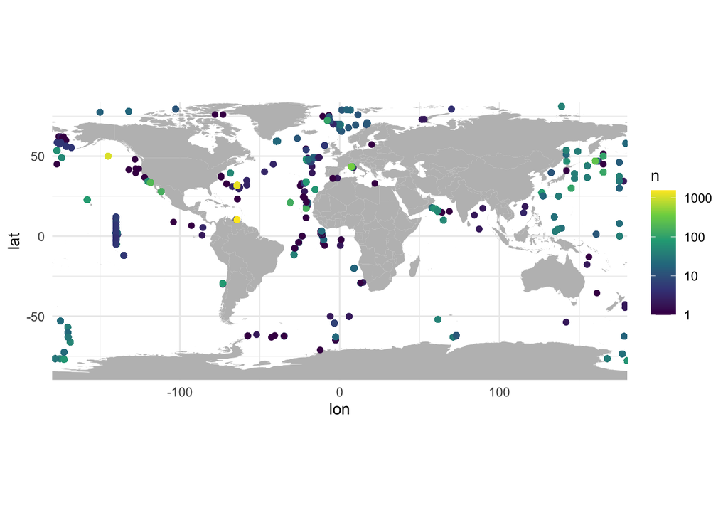

```r
df_trap %>%
  add_count(lon, lat) %>%
  ggplot() +
  geom_polygon(data = world, aes(x = lon, y = lat, group = group), fill = "grey") +
  geom_point(aes(x = lon, y = lat, colour = n)) +
  scale_colour_viridis_c(trans = "log10") +
  coord_quickmap(expand = 0)
```

Depth of sediment traps.

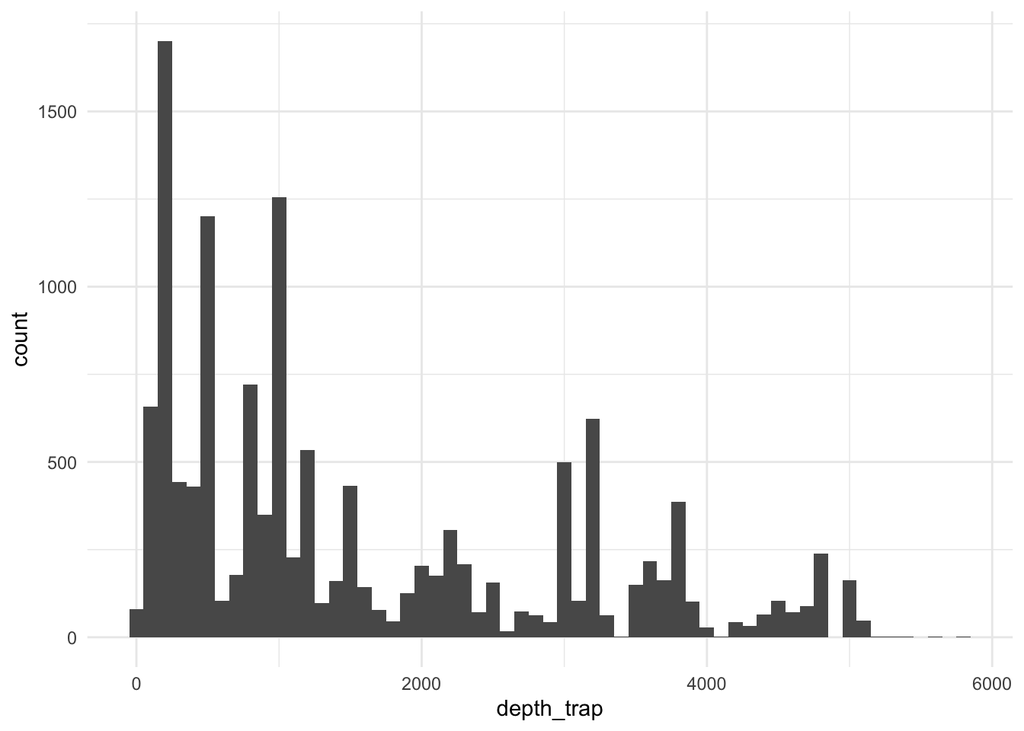

```r
ggplot(df_trap) + geom_histogram(aes(x = depth_trap), binwidth = 100)
```

Temporal aspect: deployment start date and duration.

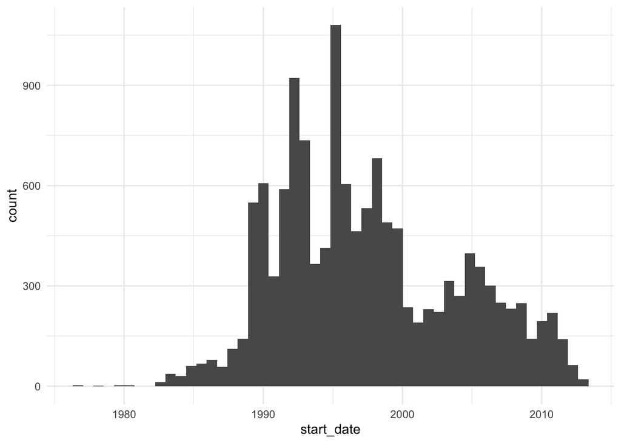

```r
ggplot(df_trap) + geom_histogram(aes(x = start_date), bins = 50)
```

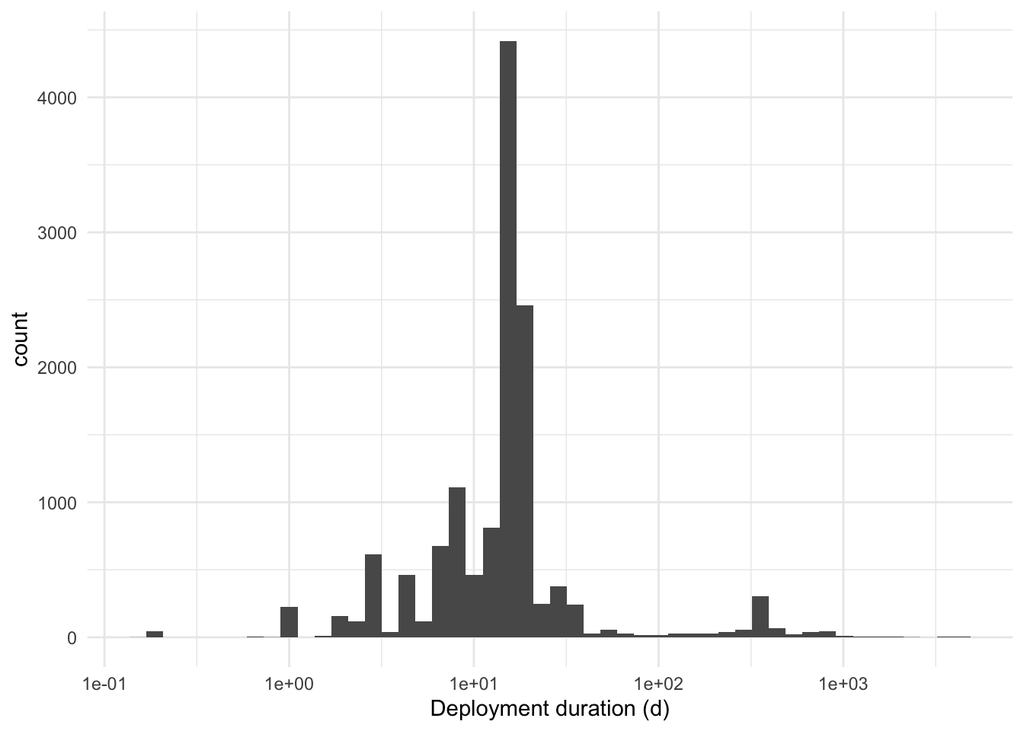

```r
ggplot(df_trap) +
  geom_histogram(aes(x = duration), bins = 50) +
  scale_x_continuous(trans = "log10") +
  labs(x = "Deployment duration (d)")
```

Flux VS depth.

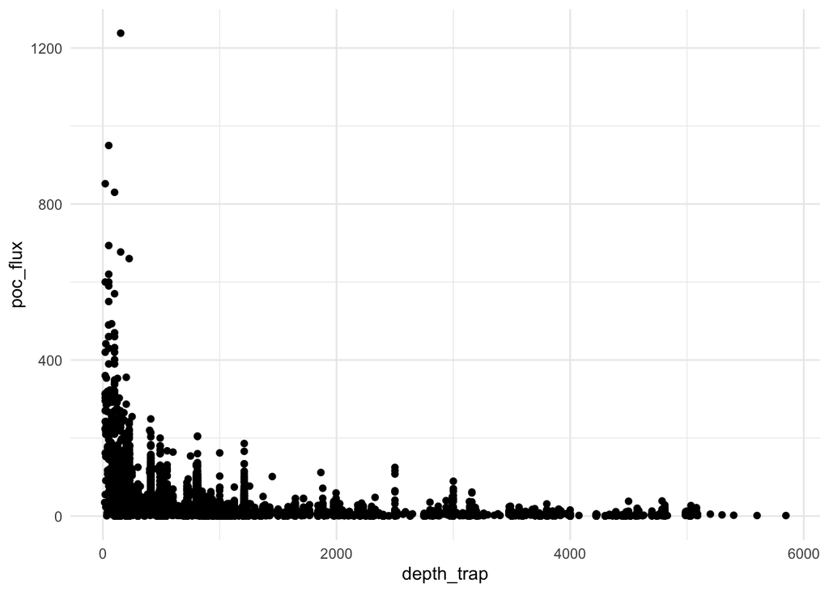

```r
ggplot(df_trap) + geom_point(aes(x = depth_trap, y = poc_flux))
```

## Read POC concentration data

Read POC concentration (mg/m³) data from [Sauzède et al., 2016](https://data.marine.copernicus.eu/product/MULTIOBS_GLO_BIO_BGC_3D_REP_015_010/description).

### Read

```r
# List NC files to read
files <- list.files("data/raw/soca/", full.names = TRUE)

# Open one file to get dims
nc <- nc_open(files[1])
lon <- ncvar_get(nc, "longitude")
lat <- ncvar_get(nc, "latitude")
depth <- ncvar_get(nc, "depth")
nc_close(nc)

# Prepare storage for 12 months
poc_mo <- array(NA, c(length(lon), length(lat), length(depth), 12))
# Read all files
for(i in 1:12) {
  # get relevant files
  file <- files[i]
  # open the file and read the data in it
  nc <- nc_open(file)
  poc_mo[,,,i] <- ncvar_get(nc, "poc")
  nc_close(nc)
}
```

### Explore

Plot surface POC in January and July.

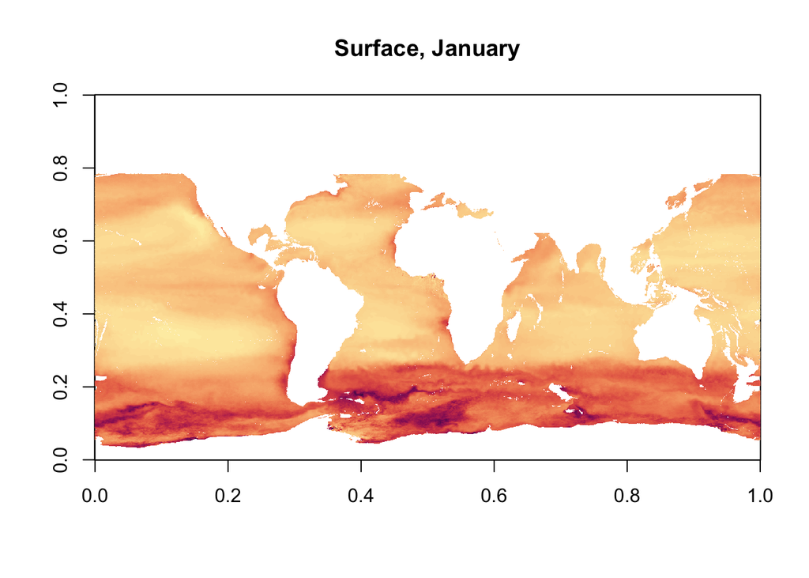

```r
image(poc_mo[,,1,1], col = cmocean("matter")(100), main = "Surface, January")
```

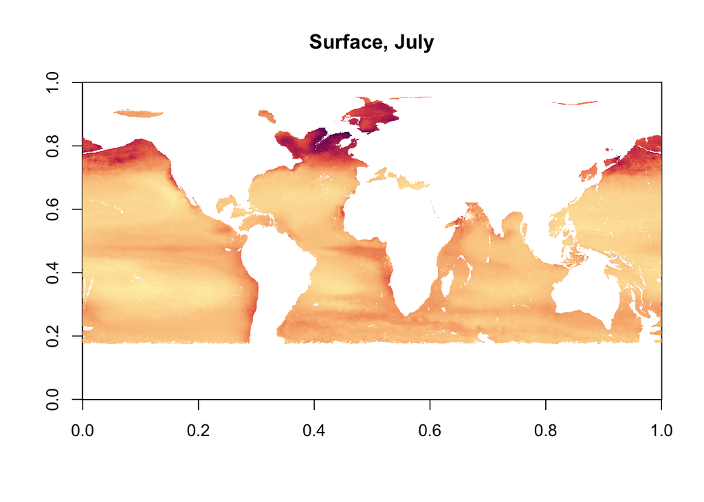

```r
image(poc_mo[,,1,7], col = cmocean("matter")(100), main = "Surface, July")
```

## Match POC flux with POC concentration profiles

### Round coordinates

First, we need to round coordinates of POC flux data to match the grid (0.25°) of the POC concentration data.

```r
# Match coordinates
df_trap <- df_trap %>%
  mutate(
    # floor longitude at 0.25 and add 0.125
    lon = roundp(lon, precision = 0.25, f = floor) + 0.125,
    # floor latitude at 0.25 and add 0.125
    lat = roundp(lat, precision = 0.25, f = floor) + 0.125
  )
```

### Match months

Sediment traps can be deployed for several months, so let’s average POC concentration profiles over the corresponding months of each deployment.

**To Do**

- consider applying a rule to include / exclude months (e.g. a deployment starting on 30/10 and ending on 21/11, then it makes no sense to include October)
- consider a weighted average based on the number of days included in each month

Get corresponding months for each deployment.

```r
df_trap <- df_trap %>%
  mutate(
    start_month = month(start_date), # beginning month
    end_month = month(end_date) # end month
  ) %>%
  rowwise() %>%
  mutate(months = list(seq(start_month, end_month))) %>% # list of months for each deployment
  ungroup()
```

Average POC concentration data over corresponding months for each POC flux observation.

```r
df_all <- pbmclapply(1:nrow(df_trap), function(i) {
  # Get line
  l <- df_trap %>% slice(i)
  # Get months to extract
  months_i <- unlist(l$months)
  # Get lon and lat
  lon_i <- l$lon
  lat_i <- l$lat

  # Get corresponding lon, lat and month in POC array
  poc_i <- poc_mo[which(lon == lon_i), which(lat == lat_i), , months_i]


  # If POC data was found, carry on
  if (length(poc_i) > 0){

    # Average over months if needed
    if (length(months_i) > 1) {
      poc_i <- apply(poc_i, 1, mean)
    }

    # Convert to dataframe and reshape to have one depth per column
    poc_i <- tibble(
      depth = depth,
      poc = poc_i
    ) %>%
      mutate(depth = paste0("poc_", depth)) %>%
      pivot_wider(names_from = depth, values_from = poc)

    # Join with POC flux data
    l %>%
      select(lon, lat, poc_flux, depth_trap) %>% # keep only lon, lat, depth and poc_flux
      bind_cols(poc_i)
}}, mc.cores = 8
) %>%
  bind_rows()
summary(df_all %>% select(lon:poc_0))
```

```
      lon                lat            poc_flux         depth_trap
 Min.   :-178.125   Min.   :-76.88   Min.   :   0.01   Min.   :  15
 1st Qu.: -68.375   1st Qu.: 10.38   1st Qu.:   2.03   1st Qu.: 480
 Median : -64.125   Median : 31.62   Median :   5.40   Median :1000
 Mean   : -29.900   Mean   : 22.89   Mean   :  17.72   Mean   :1584
 3rd Qu.:   7.625   3rd Qu.: 44.12   3rd Qu.:  15.73   3rd Qu.:2750
 Max.   : 179.125   Max.   : 81.12   Max.   :1238.00   Max.   :5847

     poc_0
 Min.   : 19.49
 1st Qu.: 32.09
 Median : 48.92
 Mean   : 57.02
 3rd Qu.: 74.69
 Max.   :185.84
 NA's   :3636
```

Some POC flux observations could not be matched. Let’s drop them.

**To Do**

- consider less strict matching rules to get more data

```r
df_all <- df_all %>% drop_na()
```

### Explore dataset

Our dataset is ready, we have 9765 observations. Let’s do a quick exploration.

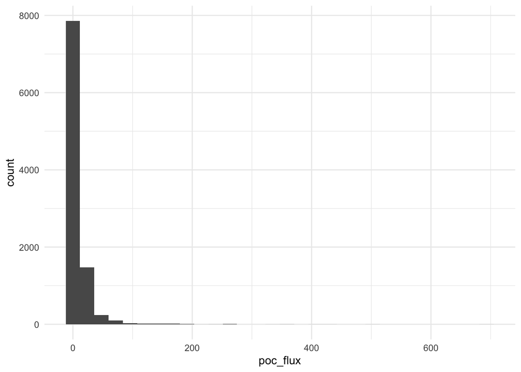

```r
## POC flux values
ggplot(df_all) + geom_histogram(aes(x = poc_flux))
```

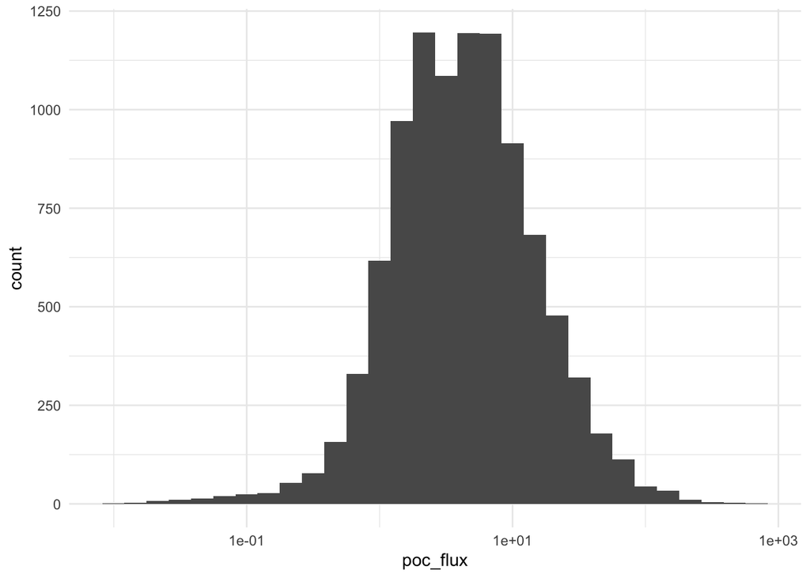

```r
# Let’s try a log-transformation
ggplot(df_all) + geom_histogram(aes(x = poc_flux)) + scale_x_continuous(trans = "log10")
```

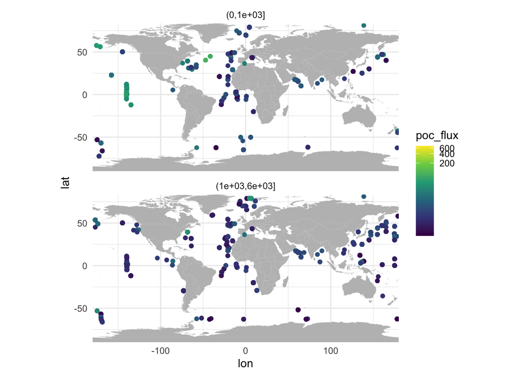

```r
# Looks good, we’ll use this!

## Various maps
df_all %>%
  mutate(depth_bin = cut(depth_trap,  breaks = c(0, 1000, 6000))) %>%
  ggplot() +
  geom_polygon(data = world, aes(x = lon, y = lat, group = group), fill = "grey") +
  geom_point(aes(x = lon, y = lat, colour = poc_flux)) +
  scale_colour_viridis_c(trans = "log1p") +
  facet_wrap(~depth_bin, ncol = 1) +
  coord_quickmap(expand = 0)
```

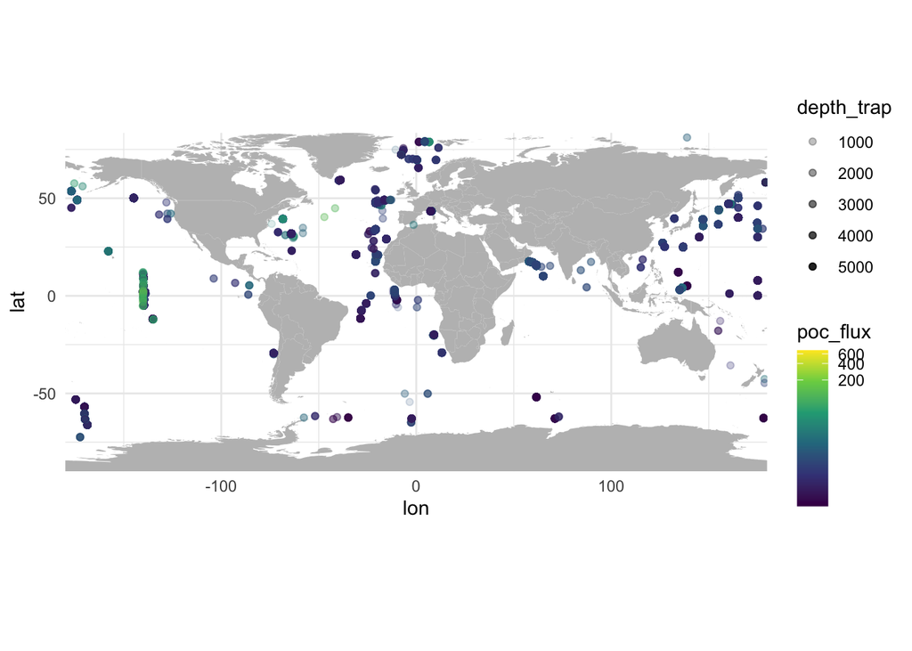

```r
df_all %>%
  ggplot() +
  geom_polygon(data = world, aes(x = lon, y = lat, group = group), fill = "grey") +
  geom_point(aes(x = lon, y = lat, colour = poc_flux, alpha = depth_trap)) +
  scale_colour_viridis_c(trans = "log1p") +
  coord_quickmap(expand = 0)
```

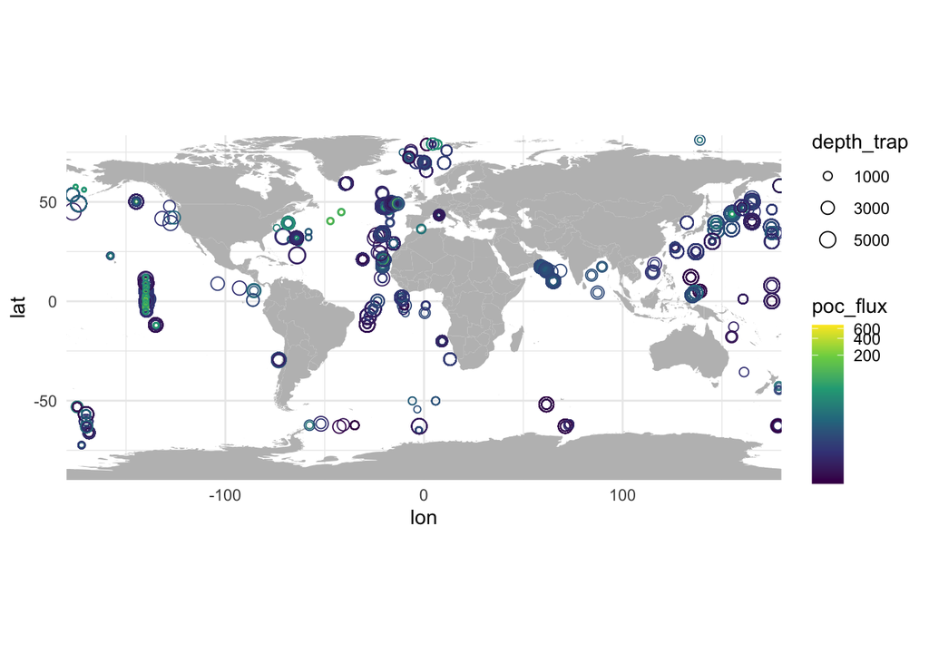

```r
df_all %>%
  ggplot() +
  geom_polygon(data = world, aes(x = lon, y = lat, group = group), fill = "grey") +
  geom_point(aes(x = lon, y = lat, colour = poc_flux, size = depth_trap), shape = 1) +
  scale_colour_viridis_c(trans = "log1p") +
  scale_size_continuous(range = c(0.5, 4), breaks = c(1000, 3000, 5000)) +
  coord_quickmap(expand = 0)
```

## Save

Save our dataset.

```r
save(df_all, file = "data/00.df_all.Rdata")
```